[figure not shown]

Dirección de Epidemiología

# Vigilancia Centinela de Infección Respiratoria Aguda Grave (IRAG)

Autor:

Dirección General de Epidemiología

# Introducción

Las infecciones respiratorias aguda grave (IRAG) son una causa significativa de morbilidad y mortalidad, afectando principalmente a niños menores de cinco años, adultos mayores y personas con enfermedades preexistentes. La vigilancia de virus respiratorios con potencial epidémico, como SARS-CoV-2, influenza y VSR, es esencial para detectar eventos inusuales y aplicar medidas de prevención y control oportunas.

La vigilancia centinela implica la recolección de datos de manera sistemática en establecimientos seleccionados, representando geográficamente y poblacionalmente a la población. La OMS recomienda implementar sistemas de vigilancia centinela para hospitalizaciones por infección respiratoria aguda grave (IRAG) integrados con pruebas de laboratorio para detectar estos virus.

Desde 2022, se han implementado redes de vigilancia para monitorear SARS-CoV-2, influenza y VSR en el país, con el objetivo de expandir y fortalecer estas redes en 2024.

# Objetivos

La Vigilancia Centinela de IRAG tiene los siguientes objetivos:

- Caracterizar las tendencias de los casos de IRAG a través de variables epidemiológicas, clínicas y del diagnóstico etiológico.
- Identificar la frecuencia, distribución e impacto de los agentes etiológicos bajo vigilancia (VSR, Influenza, SARS CoV-2) en la internación y mortalidad por IRAs.
- Identificar y analizar grupos de riesgo y comorbilidades de los casos.
- Monitorear las características de los virus circulantes (Influenza, variantes de SARS-CoV2 y VSR.) en la enfermedad grave y mortalidad.
- Disponer de la caracterización de los virus influenza que potencialmente puedan ser considerados para la composición vacunal.
- Estimar la efectividad e impacto de las intervenciones como la vacuna frente a influenza estacional y frente a COVID-19 así como la implementación de la vacunación a embarazadas frente a VSR.
- Establecer niveles de actividad umbral que sean de referencia para evaluar la transmisibilidad, gravedad e impacto de las epidemias de infecciones respiratorias agudas.
- Estimar la carga de enfermedad por infecciones respiratorias agudas asociadas a virus respiratorios para informar la asignación de recursos y contribuir a la toma de decisiones en salud pública.

```
Componentes de la Estrategia de vigilancia de infecciones respiratorias agudas
```

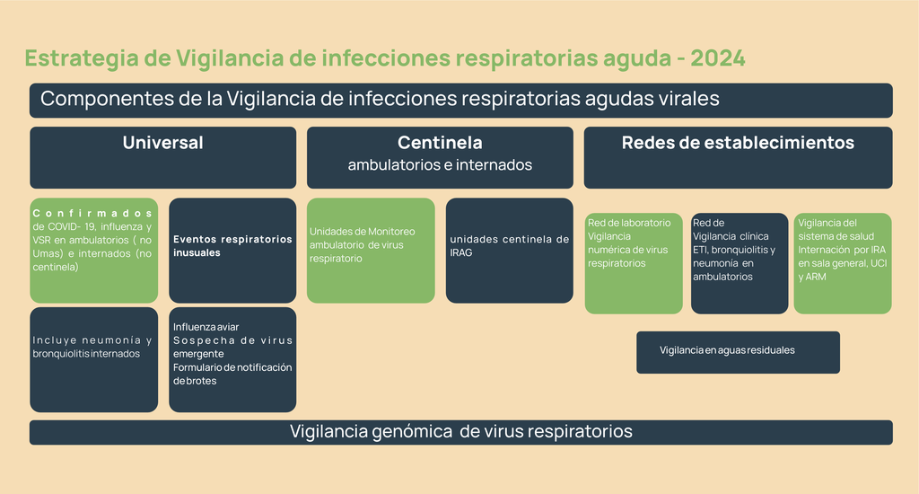

Vigilancia Centinela: Se deben notificar todos los resultados, tanto positivos como negativos, de manera nominal e individual en el SNVS 2.0 – SISA.

# Definiciones de caso

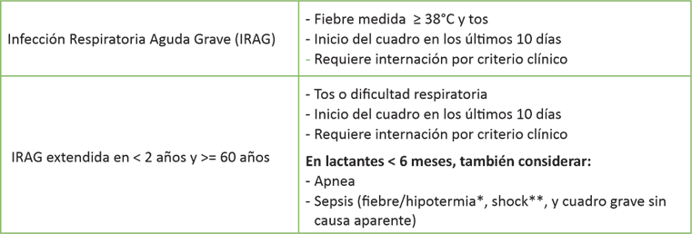

# Notificación

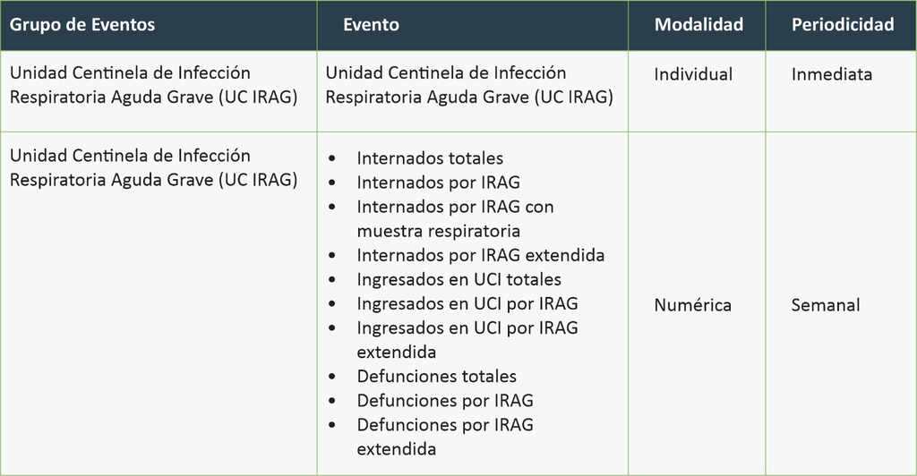

Las unidades centinela de IRAG deberán estudiar para SARS-COV-2, Influenza y VSR por métodos moleculares, y notificar a todas las personas internadas con criterio clínico de

Internación por IRAG e IRAG extendida (en <2 años y >= 60 años), completando la información clínica, epidemiológica y de laboratorio. La información clínica (signos y síntomas, comorbilidades y factores de riesgo, tratamientos), los antecedentes epidemiológicos incluyendo los antecedentes de vacunación, según los protocolos vigentes. Deberá notificarse de forma nominal, en la solapa evento la clasificación manual del caso como IRAG o IRAG extendida (según corresponda). En la sección tratamiento, consignar los tratamientos administrados en cada caso.

# Situación provincial

## Introducción

La evidencia sobre la sintomatología y los virus circulantes en pacientes diagnosticados con infección respiratoria aguda grave (IRAG), en internados es limitada y deficiente. Por ello, el objetivo de las unidades centinela es recopilar información sobre las características y distribución de la población según sexo y grupo etario, la clinica y la epidemiologia.

## Los Hospitales seleccionados en la Provincia del Neuquén son:

● HTAL PROV NEUQUÉN - DR EDUARDO CASTRO RENDÓN

● HTAL ZAPALA - DR JUAN J POSSE

● HTAL SAN MARTÍN DE LOS ANDES - DR RAMÓN CARRILLO

● HTAL BOUQUET ROLDAN

La información se recopiló a partir de los casos notificados en el sistema nacional de vigilancia sanitaria (SNVS), historia clínica de ANDES, y el sistema de laboratorio central SIL (Biología molecular).

De los pacientes estudiados por laboratorio: Determinaciones con resultado positivo, Grupo etario y sexo, signos y síntomas, comorbilidades, datos de vacunas recibidas.

## Resultados

✔ En relación a las variantes, no se identificó genoma.

## Casos de IRAG y de IRAG extendida según modalidad de notificación. Acumulado año 2025.

| Modalidad / Definición de caso | **HPN** **-Dr Eduardo Castro Rendon** | Htal San Martin de los Andes-Dr R Carrillo | Htal Zapala-Dr Juan J Pose | Htal Bouquet Roldan |
| --- | --- | --- | --- | --- |
| Nominal - Casos IRAG | 73 | 64 | 39 | 33 |
| Agrupada - Casos IRAG | 117 | 79 | 218 | 89 |
| Nominal - Casos IRAG extendida | 66 | 4 | 33 | 36 |
| Agrupada - Casos IRAG extendida | 81 | 21 | 21 | 31 |

## Indicadores basados en la notificación agrupada. Últimas 4 SE.

| Indicador | Htal Bouquet Roldan | Htal Castro Rendon | Htal San Martin de los Andes | Htal Zapala | TOTAL |
| --- | --- | --- | --- | --- | --- |
| IRAG internados | 68.0 | 27.0 | 6.0 | 43.0 | 144.0 |
| IRAG extendida internados | 28.0 | 20.0 | 3.0 | 8.0 | 59.0 |
| IRAG en UTI | 0.0 | 6.0 | 1.0 | 0.0 | 7.0 |
| IRAG extendida en UTI | 0.0 | 5.0 | 0.0 | 0.0 | 5.0 |
| IRAG fallecidos | 0.0 | 3.0 | 0.0 | 1.0 | 4.0 |
| IRAG extendida fallecidos | 1.0 | 3.0 | 0.0 | 0.0 | 4.0 |
| % hospitalizaciones por IRAG | 49.3 | 12.6 | 6.3 | 15.5 | 19.9 |
| % ingresos a UTI por IRAG |  | 9.1 | 9.1 | 0.0 | 7.7 |
| % hospitalizacion por IRAG extendida | 20.3 | 9.3 | 3.2 | 2.9 | 8.1 |
| % ingresos a UTI por IRAG extendida |  | 7.6 | 0.0 | 0.0 | 5.5 |
| % defunciones por IRAG | 0.0 | 18.8 |  | 12.5 | 11.4 |
| % defunciones por IRAG extendida | 9.1 | 18.8 |  | 0.0 | 11.4 |

## Distribución temporal de casos de IRAG totales por Hospital. Notificación agrupada. Desde SE 1/2024 hasta SE 36/2025. Provincia del Neuquén.

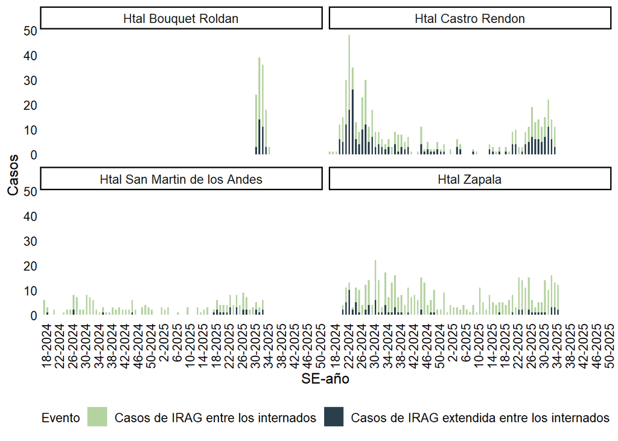

## Distribución temporal de casos de IRAG totales por Hospital. Notificación nominal. Desde SE 1/2024 hasta SE 36/2025. Provincia del Neuquén.

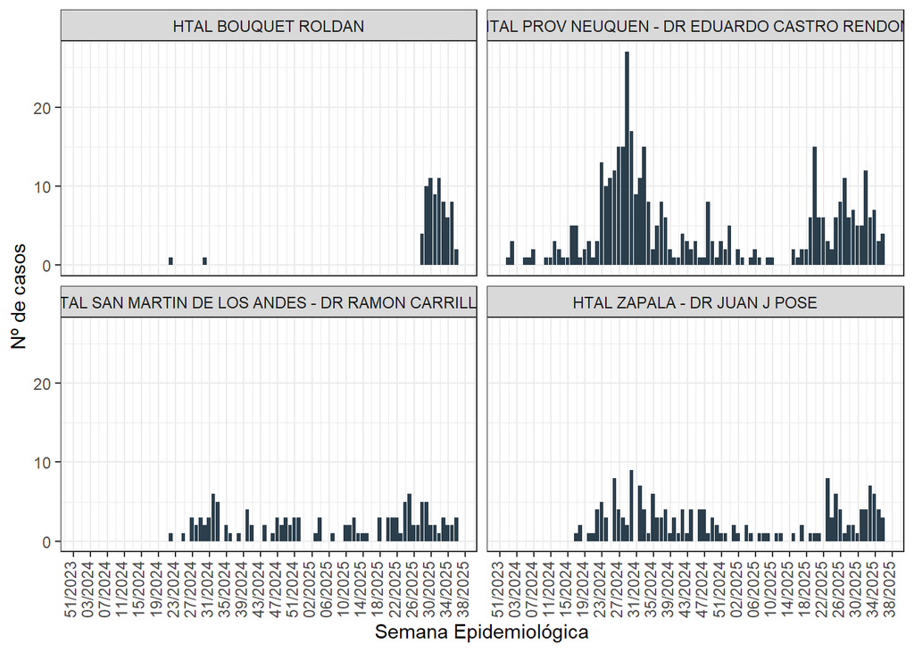

## Distribución de casos de IRAG fallecidos e internados por sexo y edad. Últimas 4 SE.

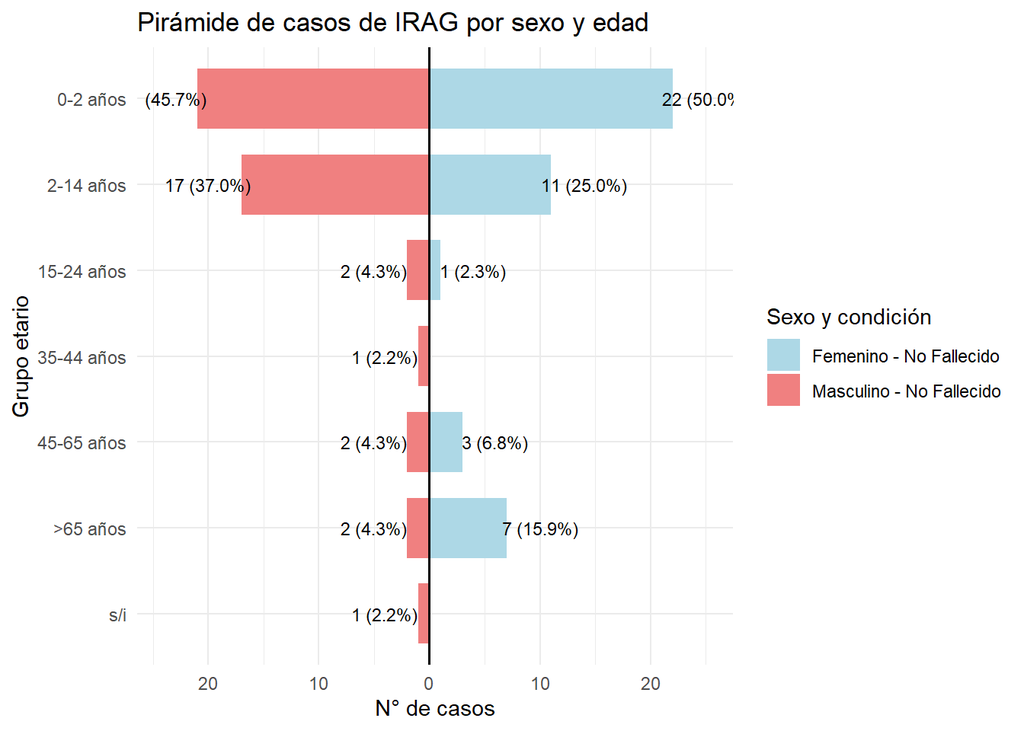

## Distribución temporal de casos de IRAG totales según resultado de laboratorio por Hospital.

Notificación nominal.Desde SE 1/2024 hasta SE 36/2025. Provincia del Neuquén.

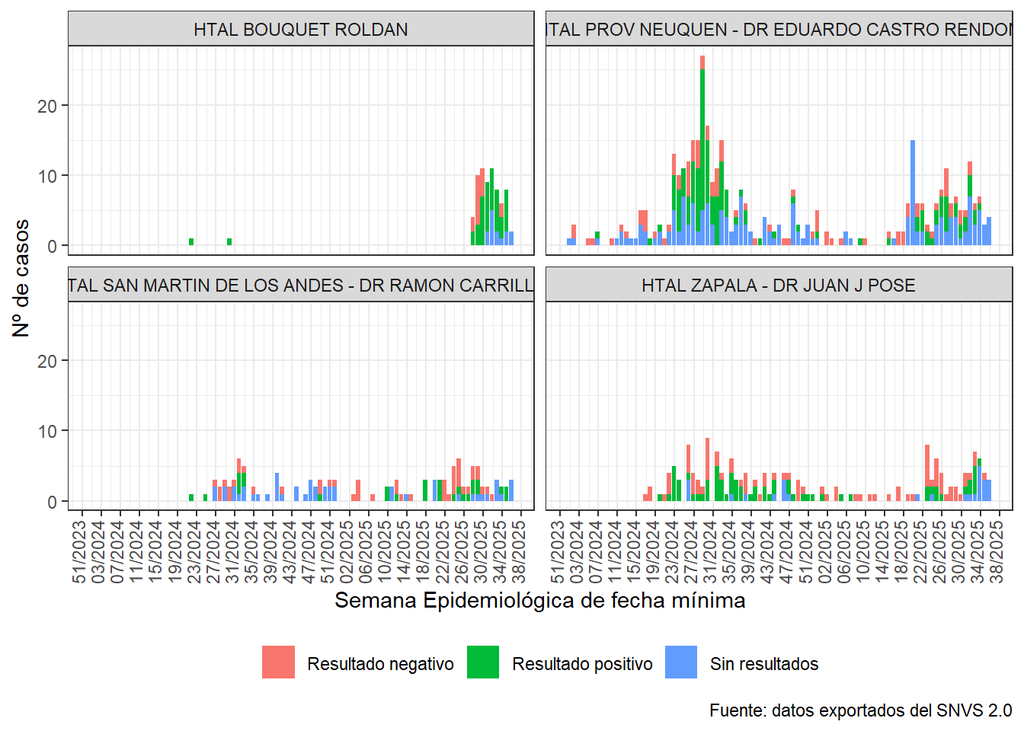

## Distribución temporal de casos de IRAG totales con resultados positivos según patógeno por Hospital.

Notificación nominal.Desde SE 1/2024 hasta SE 36/2025. Provincia del Neuquén.

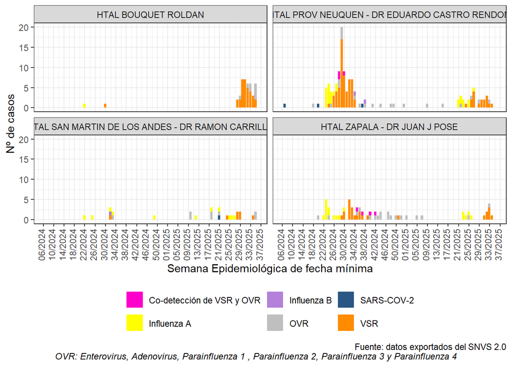

## Distribución según comorbilidades de casos de IRAG pediaricos y adultos. Notificación nominal.

Acumulado año 2025. Provincia del Neuquén (n= 341).

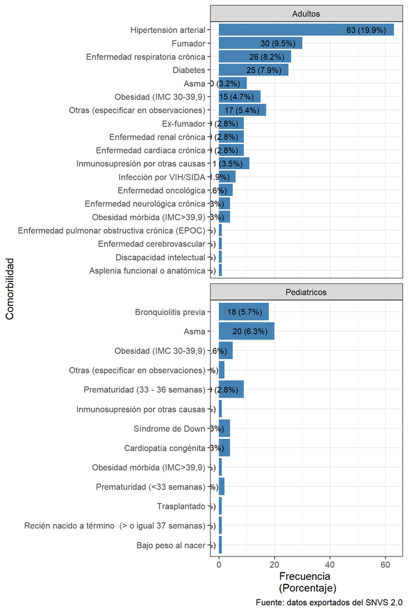

## Distribución según signos y síntomas de pacientes pediaricos y adultos. Notificación nominal.**. Acumulado año 2025. Provincia del Neuquén (n= 344).

[figure not shown]

Del total de casos de IRAG del año en curso, en 4 no se registró el dato de los signos y síntomas.

Descargar PDF

La Guía Operativa orienta la implementación y adaptación de esta estrategia.